[OHI-Northeast](http://www.ohi-northeast.org/) | [OHI Science](http://ohi-science.org) | [Citation policy](http://ohi-science.org/citation-policy/)

# OHI-Northeast: Mariculture Production Layer

Compiled on Fri Nov 22 15:04:32 2019 by afflerbach

## Summary

This script creates the mariculture production layer. This layer measures the total amount of biomass produced through mariculture by state and species. Sustainability scores for each species come from the Seafood Watch program (e.g. [Oysters](https://www.seafoodwatch.org/seafood-recommendations/groups/oysters?q=Oysters&t=Oysters&location=domestic&method=farmed&type=eastern&o=1190987422)) and are used to weight production (i.e. the more production of highly sustainable species will have a more positive impact on final scores).

## Data

Production data was gathered from available state reports (e.g. CRMC’s “[Aquaculture in Rhode Island](http://www.crmc.ri.gov/aquaculture/aquareport15.pdf)”, Massachusetts DF&G reports). Since this data often exists within PDF’s and various formats, all production data was entered by hand into a google sheet and subsequently brought into this analysis.

## Data cleaning

Since this data often exists within PDF’s and various formats, all production data was entered by hand into a google sheet and subsequently brought into this analysis.

```r
#load data
data <- read_csv("data/production.csv",
                 col_names = FALSE)

#set row 3 as column names
colnames(data) <- data[3,]

#change column names. We have two Pounds columns. I'm differentiating by adding a 2 to the second one, and then fix this a couple rows down
colnames(data) <- c("Year", "Region", "Species", "Tons", "Individuals", "Bags", "Bushels", "Pieces", "Pounds", "Value", "Source ID", NA, "Pounds", "Tons conversion")

#remove first three rows which don't contain information we need
data <- data[4:nrow(data),1:10]

#some weird characters in the Tons column
data$Tons <- gsub("~","", data$Tons)
data$Tons <- gsub(" \\+", "", data$Tons)

value_only <- data %>%
  filter(!is.na(Value) & is.na(Tons) & is.na(Individuals) & is.na(Bags) & is.na(Bushels) & is.na(Pieces) & is.na(Pounds))

#remove these rows from data_clean
data <- setdiff(data, value_only)

data %>%
  kable() %>%
  kable_styling(bootstrap_options = c("striped", "hover","condensed")) %>%
  scroll_box(width = "100%", height = "400px")
```

| Year | Region | Species | Tons | Individuals | Bags | Bushels | Pieces | Pounds | Value |
| --- | --- | --- | --- | --- | --- | --- | --- | --- | --- |
| 1988 | Maine | Atlantic Salmon | 500 | NA | NA | NA | NA | NA | No data |
| 1989 | Maine | Atlantic Salmon | 1000 | NA | NA | NA | NA | NA | No data |
| 1990 | Maine | Atlantic Salmon | 2500 | NA | NA | NA | NA | NA | No data |
| 1991 | Maine | Atlantic Salmon and Trout | 5187.2925 | NA | NA | NA | NA | NA | 28,994,373 |
| 1992 | Maine | Atlantic Salmon and Trout | 6744.598 | NA | NA | NA | NA | NA | 45,301,457 |
| 1993 | Maine | Atlantic Salmon and Trout | 7740.924 | NA | NA | NA | NA | NA | 42,156,703 |
| 1994 | Maine | Atlantic Salmon and Trout | 7048.766 | NA | NA | NA | NA | NA | 35,670,286 |
| 1995 | Maine | Atlantic Salmon and Trout | 11124.838 | NA | NA | NA | NA | NA | 56,321,667 |
| 1996 | Maine | Atlantic Salmon and Trout | 11046.768 | NA | NA | NA | NA | NA | 46,243,911 |
| 1997 | Maine | Atlantic Salmon and Trout | 13482.4215 | NA | NA | NA | NA | NA | 49,140,048 |
| 1998 | Maine | Atlantic Salmon and Trout | 14574.6505 | NA | NA | NA | NA | NA | 60,537,109 |
| 1999 | Maine | Atlantic Salmon and Trout | 13499.20135 | NA | NA | NA | NA | NA | 57,945,146 |
| 2000 | Maine | Atlantic Salmon and Trout | 18145.077 | NA | NA | NA | NA | NA | 78,948,352 |
| 2001 | Maine | Atlantic Salmon | 14552.768 | NA | NA | NA | NA | NA | 58,211,072 |
| 2002 | Maine | Atlantic Salmon | 7493.9185 | NA | NA | NA | NA | NA | 16,936,256 |
| 2003 | Maine | Atlantic Salmon | 6621.7095 | NA | NA | NA | NA | NA | 28,208,482 |
| 2004 | Maine | Atlantic Salmon | 9386.519 | NA | NA | NA | NA | NA | 39,986,570 |
| 2005 | Maine | Atlantic Salmon | 5801.218 | NA | NA | NA | NA | NA | 23,204,872 |
| 2006 | Maine | Atlantic Salmon | 5151.972 | NA | NA | NA | NA | NA | 20,607,888 |
| 2007 | Maine | Atlantic Salmon | 4281.1385 | NA | NA | NA | NA | NA | 21,405,693 |
| 2008 | Maine | Atlantic Salmon | 9936.6615 | NA | NA | NA | NA | NA | 49,683,308 |
| 2009 | Maine | Atlantic Salmon | 6779.7355 | NA | NA | NA | NA | NA | 37,288,545 |
| 2010 | Maine | Atlantic Salmon | 12265.47 | NA | NA | NA | NA | NA | 73,592,820 |
| 2005 | Maine | Blue Mussel | 699.754 | NA | NA | NA | NA | NA | $951,269 |
| 2006 | Maine | Blue Mussel | 581.8815 | NA | NA | NA | NA | NA | $553,520 |
| 2007 | Maine | Blue Mussel | 948.08 | NA | NA | NA | NA | NA | $653,867 |
| 2008 | Maine | Blue Mussel | 316.165 | NA | NA | NA | NA | NA | $664,822 |
| 2009 | Maine | Blue Mussel | 471.752 | NA | NA | NA | NA | NA | $1,177,738 |
| 2010 | Maine | Blue Mussel | 701.304 | NA | NA | NA | NA | NA | $1,344,652 |
| 2011 | Maine | Blue Mussel | 355.4395 | NA | NA | NA | NA | NA | $851,814 |

[output cut: 221 more lines]

Some of the species are entered with different common names. For example we have “American Oyster”, “Eastern Oyster” and “Oysters”. This chunk just fixes some of that for oysters, scallops and clams.

```r
#convert character to numeric. Clean up species names and convert tons to pounds
data_clean <- data %>%
  mutate(Tons = as.numeric(Tons),
         Individuals = as.numeric(gsub(",","", Individuals)),
         Bags = as.numeric(gsub(",","", Bags)),
         Bushels = as.numeric(gsub(",", "", Bushels)),
         Pieces  = as.numeric(gsub(",", "", Pieces)),
         Pounds  = as.numeric(gsub(",", "", Pounds))) %>%
  mutate(species =
           case_when(
             Species == "American Oyster" ~ "Oysters",
             Species == "Eastern Oyster" ~ "Oysters",
             Species == "bay scallops" ~ "Scallops",
             Species == "soft shell clams" ~ "Soft Shell Clams",
             Species == "Quahog" ~ "Hard Clam",
             Species == "Clams" ~ "Hard Clam"
           )) %>%
  mutate(Species_name_to_use = ifelse(is.na(species), Species, species),
         pounds = Tons*2000,
         Pounds = ifelse(is.na(Pounds), pounds, Pounds)) %>%
  filter(!is.na(Year)) #there are two records for CT where there is no year..
```

### What species do not have tons or pounds information?

A lot of the data is entered as **Individuals**, **Bags** or **Bushels** for these species

```r
miss_lbs <- data_clean %>%
  filter(is.na(Pounds))

unique(miss_lbs$Species_name_to_use)
```

```
## [1] "Atlantic Salmon"                 "Oysters"
## [3] "Hard Clam"                       "All shellfish aquaculture"
## [5] "Shellfish (oysters and quahogs)" "Soft Shell Clams"
## [7] "Scallops"
```

Unfortunately, we need some sort of weight metric. We can convert these units to pounds using a conversion table that we put together.

#### Weight Conversion Table

```r
#load the weight conversion table
conv <- read.csv("data/weight_conversion_table.csv")

conv %>%
  kable() %>%
  kable_styling(bootstrap_options = c("striped", "hover","condensed"), full_width = F)
```

| Species | Pounds | Bushel | Bag | Individual |
| --- | --- | --- | --- | --- |
| Hard Clam | 1 | 0.017 | 0.048 | 10.00 |
| Quahog | 1 | 0.017 | NA | 10.00 |
| Soft Shell Clams | 1 | 0.020 | NA | NA |
| Bay Scallop | 1 | 0.014 | NA | NA |
| Oysters | 1 | 0.017 | 0.017 | 2.36 |
| Clams | 1 | 0.017 | NA | NA |
| Scallops | 1 | 0.014 | NA | NA |

### Convert to pounds

This chunk uses the conversion table to convert all units to pounds.

```r
spp <- unique(conv$Species)

convert_to_pounds <- function(sp) {
sp_conv <- filter(conv, Species == sp)

  out <- data_clean %>%
  filter(Species_name_to_use == sp) %>%
  mutate(pounds =
           case_when(
             !is.na(Individuals) ~ Individuals/sp_conv$Individual,
             !is.na(Bags) ~ Bags/sp_conv$Bag,
             !is.na(Bushels) ~ Bushels/sp_conv$Bushel,
             !is.na(Pounds) ~ Pounds,
             !is.na(Pieces) ~ Pieces/sp_conv$Individual
           )) %>%
    select(Year, Region, Species, Species_name_to_use, pounds)

  return(out)
}

hclam <- convert_to_pounds("Hard Clam")
oyster <- convert_to_pounds("Oysters")
scallop <- convert_to_pounds("Scallops")
ss_clams <- convert_to_pounds("Soft Shell Clams")

combo <- bind_rows(hclam, oyster, scallop, ss_clams)
```

### Fix Maine finfish data

Due to weird data reporting for Salmon and Trout, we need to fix Maine’s finfish. The `maine_finfish.csv` dataset is used to replace all finfish from Maine. We also use the 2010 data to gapfill forward since the Department of Marine Resources does not report production data after 2010 due to confidentiality statutes ([see their statment here](https://www.maine.gov/dmr/aquaculture/harvestdata/index.html)). But this is done in the gapfilling section below.

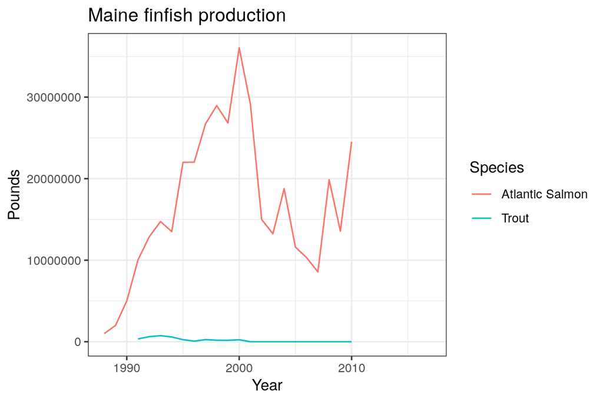

```r
#read in the Maine finfish data
maine_ff <- read_csv("data/maine_finfish.csv") %>%
  rename(pounds = `Whole Pounds`) %>%
  complete(Year = 1988:2017) %>%
  mutate(Species = ifelse(is.na(Species), "Atlantic Salmon", Species),
         Region = "Maine")

ggplot(maine_ff, aes(x = Year, y = pounds, color = Species)) +
  geom_line() +
  theme_bw() +
  labs(title = "Maine finfish production",
       y = "Pounds")
```

Now we have the data cleaned up and can look at production by species and state over time.

```r
remaining_sp <- data_clean %>%
    filter(!is.na(pounds)) %>%
    select(Year, Region, Species, Species_name_to_use, pounds)

production_df <- full_join(combo, remaining_sp) %>%
    mutate(Year = as.numeric(Year)) %>%
    filter(!Species_name_to_use %in% c("Atlantic Salmon and Trout", "Atlantic Salmon", "Shellfish", "Mussels, clams, quahogs, and other shellfish (not including oysters)")) %>%
    select(Year, Region, Species = Species_name_to_use, pounds) %>%
  bind_rows(maine_ff)

write_csv(production_df, "data/production_clean.csv")
```

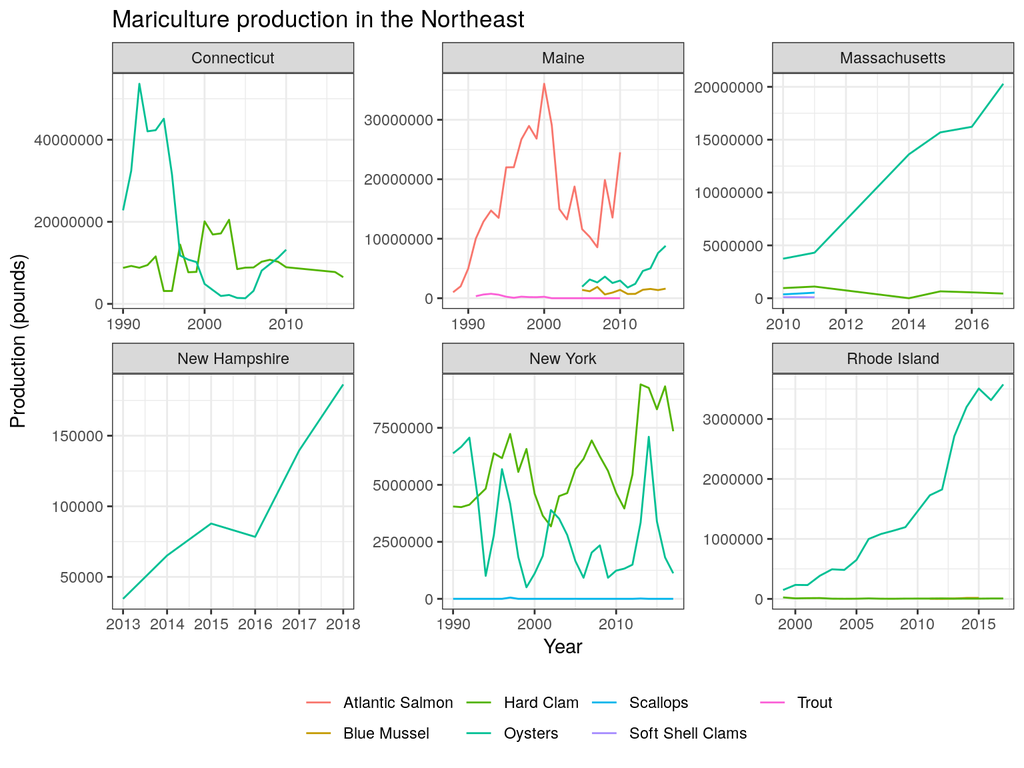

```r
ggplot(production_df, aes(x = Year, y = pounds, color = Species)) +
  geom_line() +
  theme_bw() +
  ylab("Production (pounds)") +
  ggtitle("Mariculture production in the Northeast") +
  facet_wrap(~Region, scales = "free") +
  theme(legend.position = "bottom",
        legend.title=element_blank())
```

Bargraph

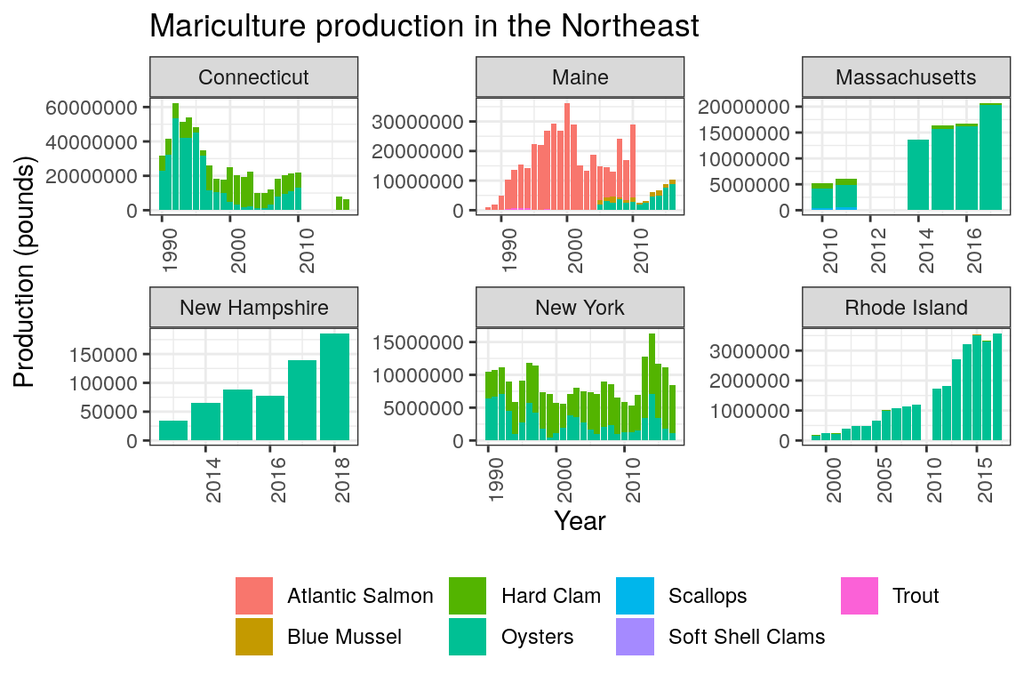

```r
bargraph <- ggplot(production_df, aes(x = Year, y = pounds, fill = Species)) +
  geom_bar(stat="identity" ) +
  theme_bw() +
  ylab("Production (pounds)") +
  ggtitle("Mariculture production in the Northeast") +
  facet_wrap(~Region, scales = "free") +
  theme(legend.position = "bottom",
        legend.title=element_blank(),
        axis.text.x = element_text(angle = 90, hjust = 1))
bargraph
```

## Gapfilling

We need to gapfill for years where there is no reported production. If there is a year without production between two years of production, we assume there was some. Let’s first take a look at what needs gapfilling.

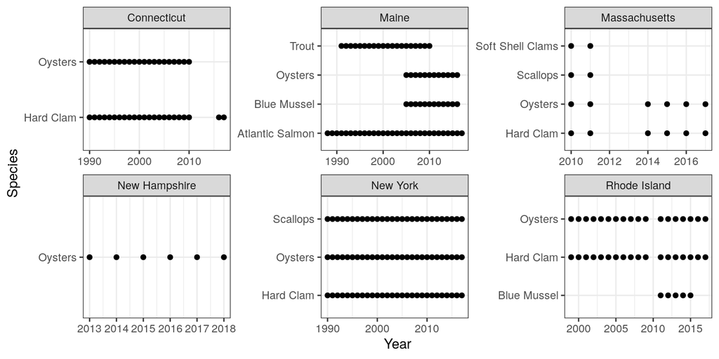

```r
ggplot(production_df, aes(x = Year, y = Species)) +
  geom_point() +
  facet_wrap(~Region, scales = "free") +
  theme_bw()
```

Massachusetts is missing 2012 and 2013 for Hard Clam and Oysters, Rhode Island is missing 2010 for Oysters and Hard Clam.

We don’t know if these are 0’s or missing data. We need to **gapfill** this missing data. When a species/state combination has missing data for a year, we can not assume it has a production of 0. Since we calculate a rolling average of production, NAs will remain as NA’s and the average will rely on just one or two years of catch. This is done to account for any wild fluctuations in catch year to year.

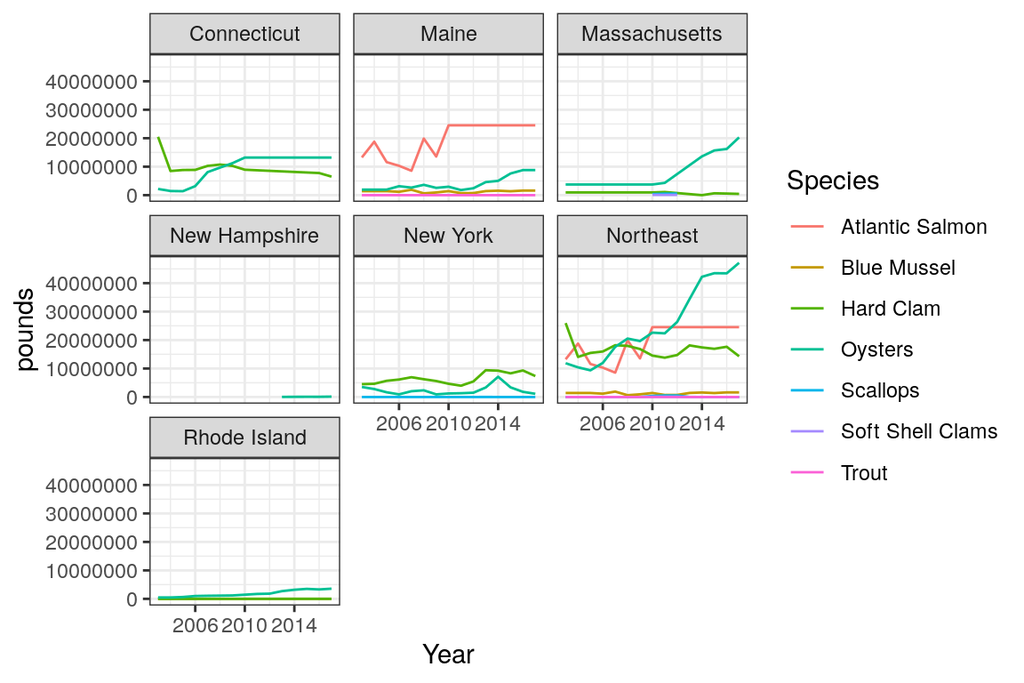

```r
production_gf <- production_df %>%
  group_by(Region, Species) %>%
  complete(Year = 2003:2017) %>%
  mutate(pounds = zoo::na.approx(pounds, na.rm = FALSE)) %>% #first apply a linear interpolation between points
  mutate(pounds2 = zoo::na.locf(zoo::na.locf(pounds, na.rm = FALSE), fromLast =TRUE)) %>% #carried first value backwards when we don't have previous years, and last value forwards when we don't have future estimates
  ungroup() %>%
  mutate(pounds = ifelse(
   Region == "New Hampshire" & Year < 2013, NA, #no evidence of farming before 2013
    ifelse(Region == "Massachusetts" & Species %in% c("Soft Shell Clams", "Scallops") & !Year %in% c(2010:2012), NA, pounds2))) %>%
  select(-pounds2)

#production for whole northeast
ne_prod <- production_gf %>%
  group_by(Species, Year) %>%
  summarize(pounds = sum(pounds, na.rm = T)) %>%
  ungroup() %>%
  mutate(Region = "Northeast")

prod_gf <- bind_rows(production_gf, ne_prod)

ggplot(prod_gf, aes(x = Year, y = pounds, color = Species)) +
  geom_line() +
  theme_bw() +
  facet_wrap(~Region)
```

## Get 3 year rolling mean

We apply a three year rolling mean to account for year to year variability.

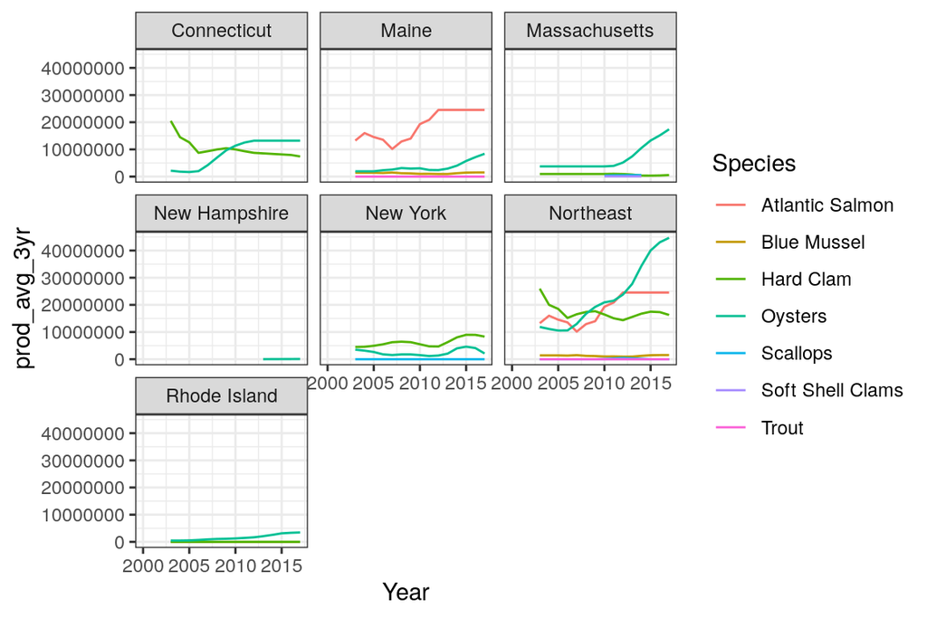

```r
prod_3yr <- prod_gf %>%
  filter(Year > 2000) %>%
  arrange(Year) %>%
  group_by(Region, Species) %>%
  complete(Year = 2000:2017) %>%
  mutate(prod_avg_3yr = zoo::rollapply(pounds, 3, FUN = mean, align = "right", na.rm = T, partial = T), #calculate the mean for three years
         yr_num       = 1:n(), #need to remove the first two years, so add a column that identifies where in the sequence the year is
         last_years_prod = lag(prod_avg_3yr, n = 1)) %>%
  ungroup()

ggplot(prod_3yr, aes(x = Year, y = prod_avg_3yr, color = Species)) +
  geom_line() +
  theme_bw() +
  facet_wrap(~Region)
```

## Save to toolbox

```r
out <- prod_3yr %>%
  left_join(rgn_data, by = c("Region" = "state")) %>%
  mutate(rgn_id = ifelse(Region == "Northeast", 12, rgn_id)) %>%
  select(year = Year, rgn_id, Species, production = prod_avg_3yr, yr_num, last_years_prod)

write_csv(out, "~/github/ne-scores/region/layers/mar_production.csv")
```